# R Notebook: Getting Dirty with Data

# Goal today: Use R Markdown to investigate a data question!

These data are originally from Kaggle (https://www.kaggle.com/dorbicycle/world-foodfeed-production). Laurel Brehm has done some reformatting & cleaning, & has uploaded the results to RLadies GitHub.

The data were collected from Food and Agriculture Organization of the United Nations. We have production in 1000 tonnes of *food* (=for people) and *feed* (=for animals), per country over years. There is also data about the country location (latitude and longitude).

## Data Summary

What do these data look like?

| Area.Abbreviation | Area | Item | Element | latitude | longitude | Year | KTonnes | Crop |
| --- | --- | --- | --- | --- | --- | --- | --- | --- |
| AFG | Afghanistan | Wheat and products | Food | 33.94 | 67.71 | 1961 | 1928 | Grains |
| AFG | Afghanistan | Rice (Milled Equivalent) | Food | 33.94 | 67.71 | 1961 | 183 | Grains |
| AFG | Afghanistan | Barley and products | Feed | 33.94 | 67.71 | 1961 | 76 | Grains |
| AFG | Afghanistan | Barley and products | Food | 33.94 | 67.71 | 1961 | 237 | Grains |
| AFG | Afghanistan | Maize and products | Feed | 33.94 | 67.71 | 1961 | 210 | Grains |
| AFG | Afghanistan | Maize and products | Food | 33.94 | 67.71 | 1961 | 403 | Grains |

What are the countries? What are the crops & food-stuffs?

```
##   [1] "Afghanistan"
##   [2] "Albania"
##   [3] "Algeria"
##   [4] "Angola"
##   [5] "Antigua and Barbuda"
##   [6] "Argentina"
##   [7] "Armenia"
##   [8] "Australia"
##   [9] "Austria"
##  [10] "Azerbaijan"
##  [11] "Bahamas"
##  [12] "Bangladesh"
##  [13] "Barbados"
##  [14] "Belarus"
##  [15] "Belgium"
```

[output cut: 159 more lines]

| Crop | Item |
| --- | --- |
| Alcohol | Alcoholic Beverages |
| Alcohol | Beer |
| Alcohol | Beverages, Alcoholic |
| Alcohol | Beverages, Fermented |
| Alcohol | Wine |
| Beans | Beans |
| Beans | Soyabeans |
| Cocoa Beans | Cocoa Beans and products |
| Coffee | Coffee and products |
| Dairy | Butter, Ghee |
| Dairy | Cream |
| Dairy | Milk - Excluding Butter |
| Eggs | Eggs |
| Fruit | Apples and products |
| Fruit | Bananas |
| Fruit | Citrus, Other |
| Fruit | Dates |
| Fruit | Fruits - Excluding Wine |
| Fruit | Fruits, Other |
| Fruit | Grapefruit and products |
| Fruit | Grapes and products (excl wine) |
| Fruit | Lemons, Limes and products |
| Fruit | Oranges, Mandarines |
| Fruit | Pineapples and products |
| Grains | Barley and products |
| Grains | Cereals - Excluding Beer |
| Grains | Cereals, Other |
| Grains | Maize and products |
| Grains | Millet and products |
| Grains | Oats |

[output cut: 85 more lines]

## Embed a plot or picture!

[figure not shown]

## Take some stuff from R and put it in text!

```r
# in this chunk, I asked the output to be shown with echo=TRUE
# Get the maximum value of a product, with function max().
# Need to set na.rm=T because there are NA values in the column.
m <- max(ds$KTonnes,na.rm=T)

# Then look up which area has that value for the column KTonnes
a <- ds[ds$KTonnes %in% m ,]$Area

# And which item it is
i <- ds[ds$KTonnes %in% m ,]$Item

# And which year!
y <- ds[ds$KTonnes %in% m ,]$Year

# Then, we can use those values in text by surrounding with `` and prefacing with r
```

The single largest export in a year was from China, mainland in 2013 and it was 4.8929910^{8} tonnes of Vegetables.

# The goal for today is to investigate food / feed production over time by countries.

Summarise some data, plot some data, and find some patterns!

## Questions to ask:

- Pick a food type and look at where it’s grown over time
- Pick a country and find what’s been grown in it over time
- Pick a year and see what’s been grown where
- Look at differences in food (for people) vs feed (for animals) for a country or set of countries

## For advanced R users: Go forth on your own from here!

## For beginners… here are some code chunks to use to get you started.

# Data Summarising

```r
# in this chunk, I asked everything to be shown with echo=TRUE
# Here are some useful tabulation commands. These use the tidyverse.
# This takes data and summarises for output.
# %>% is a 'pipe' and passes commands between lines.

# you can filter columns. here, we want columns where the item is sugar cane, used for food
t2 <- ds %>%
  filter(Item=="Sugar cane") %>%
  filter(Element=="Food")

t2
```

| Area.Abbreviation | Area | Item | Element | latitude | longitude | Year | KTonnes | Crop |
| --- | --- | --- | --- | --- | --- | --- | --- | --- |
| BGD | Bangladesh | Sugar cane | Food | 23.68 | 90.36 | 1961 | 179 | Sugar |
| BWA | Botswana | Sugar cane | Food | -22.33 | 24.68 | 1961 | 0 | Sugar |
| BRA | Brazil | Sugar cane | Food | -14.24 | -51.93 | 1961 | 220 | Sugar |
| BRN | Brunei Darussalam | Sugar cane | Food | 4.54 | 114.73 | 1961 | 0 | Sugar |
| KHM | Cambodia | Sugar cane | Food | 12.57 | 104.99 | 1961 | 46 | Sugar |
| CMR | Cameroon | Sugar cane | Food | 7.37 | 12.35 | 1961 | 47 | Sugar |
| CHN | China, Hong Kong SAR | Sugar cane | Food | 22.40 | 114.11 | 1961 | 0 | Sugar |
| CHN | China, Macao SAR | Sugar cane | Food | 22.20 | 113.54 | 1961 | 0 | Sugar |
| CHN | China, Taiwan Province of | Sugar cane | Food | 23.70 | 120.96 | 1961 | 226 | Sugar |
| COD | Congo | Sugar cane | Food | -0.23 | 15.83 | 1961 | 3 | Sugar |

[output cut: 2640 more lines]

```r
# you can use a | operator ('or') to look at multiple selections at once.
# you can use the select operator to only show some columns
# and the filter operator to remove columns even after summarising
# here we ask for only the crops of more than 10*1000 tonnes
t3<- ds %>%
  filter(Area=="Netherlands" | Area=="Belgium") %>%
  group_by(Area,Crop,Element,Year) %>%
  summarise(TotalKTonnes = sum(as.numeric(KTonnes)) ) %>%
  filter(TotalKTonnes > 10)

t3
```

| Area | Crop | Element | Year | TotalKTonnes |
| --- | --- | --- | --- | --- |
| Belgium | Alcohol | Food | 2000 | 2618 |
| Belgium | Alcohol | Food | 2001 | 2590 |
| Belgium | Alcohol | Food | 2002 | 2512 |
| Belgium | Alcohol | Food | 2003 | 2483 |
| Belgium | Alcohol | Food | 2004 | 2521 |
| Belgium | Alcohol | Food | 2005 | 2722 |
| Belgium | Alcohol | Food | 2006 | 2604 |
| Belgium | Alcohol | Food | 2007 | 2478 |
| Belgium | Alcohol | Food | 2008 | 2416 |
| Belgium | Alcohol | Food | 2009 | 2455 |

[output cut: 1829 more lines]

```r
# We can make lists and use these to filter.
# Here's list of some things eaten by people and animals
mixed <- c("Oats","Soyabeans", "Sugar cane")

# this will generate an error, but it actually works.
#an example of tidyverse 'lazy evaluation'
t4<- ds %>%
  filter(Area=="Brazil" | Area=="Colombia") %>%
  filter(Item==mixed)
t4
```

| Area.Abbreviation | Area | Item | Element | latitude | longitude | Year | KTonnes | Crop |
| --- | --- | --- | --- | --- | --- | --- | --- | --- |
| BRA | Brazil | Oats | Food | -14.24 | -51.93 | 1961 | 30 | Grains |
| BRA | Brazil | Sugar cane | Feed | -14.24 | -51.93 | 1961 | 11300 | Sugar |
| BRA | Brazil | Soyabeans | Feed | -14.24 | -51.93 | 1961 | 46 | Beans |
| COL | Colombia | Soyabeans | Food | 4.57 | -74.30 | 1961 | 0 | Beans |
| BRA | Brazil | Sugar cane | Food | -14.24 | -51.93 | 1962 | 220 | Sugar |
| BRA | Brazil | Soyabeans | Food | -14.24 | -51.93 | 1962 | 3 | Beans |
| COL | Colombia | Oats | Food | 4.57 | -74.30 | 1962 | 5 | Grains |
| COL | Colombia | Sugar cane | Feed | 4.57 | -74.30 | 1963 | 16 | Sugar |
| BRA | Brazil | Oats | Food | -14.24 | -51.93 | 1964 | 28 | Grains |
| BRA | Brazil | Sugar cane | Feed | -14.24 | -51.93 | 1964 | 15000 | Sugar |

[output cut: 133 more lines]

```r
# finally, we can put these together to summarise.
# Here, we are taking mass of items grown in Brazil or Colombia
# and taking together the sum of all tonnes by year across rows
# (= total production in these countries, whether for food or feed)
# (Note that I used a less lazy evaluaton method here for the filter)

t5<- ds %>%
  filter(Item %in% mixed == T) %>%
  filter(Area=="Brazil" | Area=="Colombia") %>%
  group_by(Year,Item) %>%
  summarise(TotalKTonnes = sum(as.numeric(KTonnes))  )

t5
```

| Year | Item | TotalKTonnes |
| --- | --- | --- |
| 1961 | Oats | 37 |
| 1961 | Soyabeans | 49 |
| 1961 | Sugar cane | 11537 |
| 1962 | Oats | 36 |
| 1962 | Soyabeans | 68 |
| 1962 | Sugar cane | 15738 |
| 1963 | Oats | 33 |
| 1963 | Soyabeans | 84 |
| 1963 | Sugar cane | 17246 |
| 1964 | Oats | 35 |

[output cut: 149 more lines]

%%newpage is a command for Latex. to see what tfis does, try knitting to pdf, which uses Latex. …and % is the comment character for Latex.

## Plotting

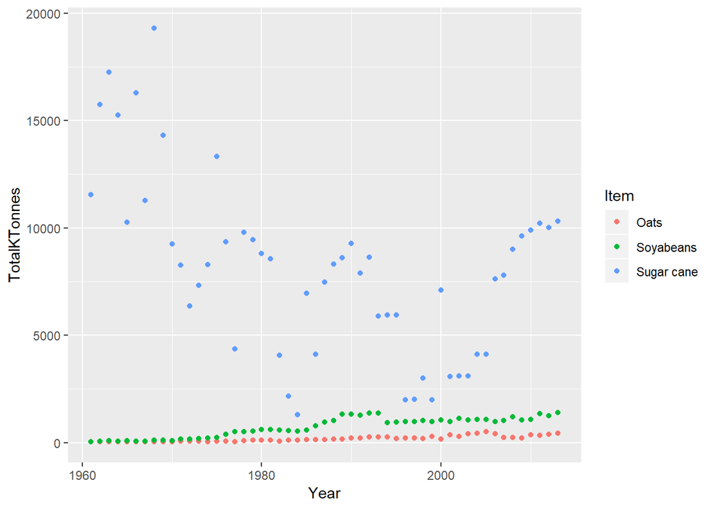

```r
# We can easily plot these with lines, points, and bars!
# we are using ggplot here.
#The first line sets up what the data are & what values are mapped to things
# in the plot ('aes' values).
# variables that are useful include: x, y values, color, lty (=line type)
# we can then add points or lines or bars with geom_point, geom_line, geom_bar

ggplot(data=t5,aes(x=Year,y=TotalKTonnes,color=Item))+
  geom_point()
```

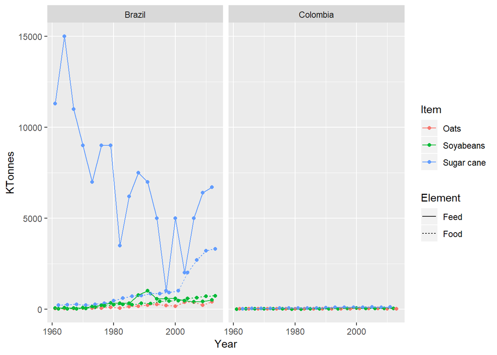

```r
# add connector lines
# and make separate panels with facet_grid
#(explore what the ~ does by trying .~Area vs Area~.)
ggplot(data=t4,aes(x=Year,y=KTonnes,color=Item,lty=Element))+
  geom_point()+
  geom_line()+
  facet_grid(.~Area)
```

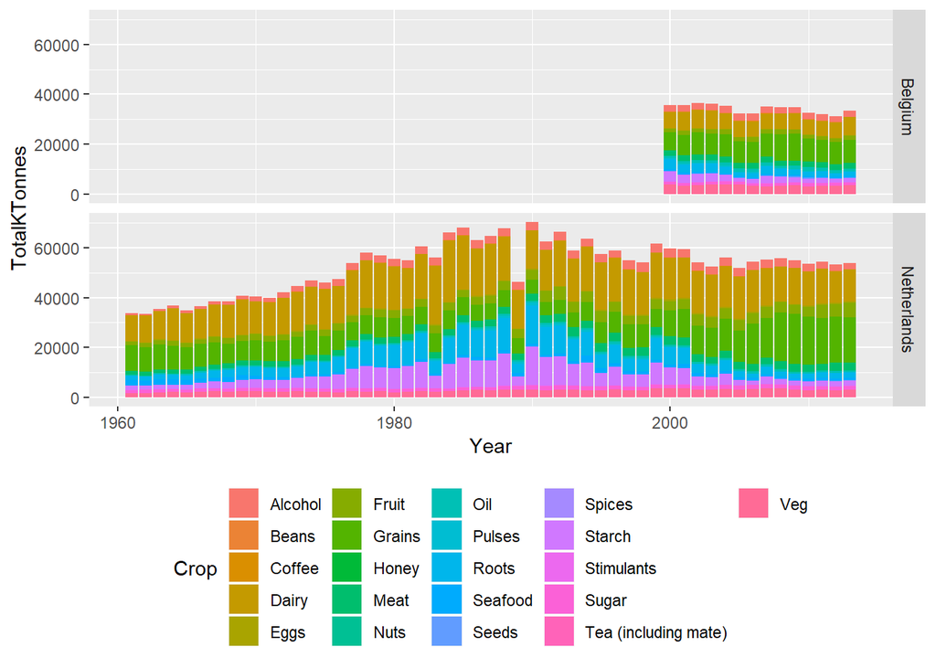

```r
# Here's an example of a bar plot
# And an example of user-specified figure height / width
ggplot(data=t3,aes(x=Year,y=TotalKTonnes,fill=Crop))+
  geom_bar(stat='identity')+
  facet_grid(Area~.)+
  theme(legend.position="bottom")
```

## Tables of output

```r
#Most of what we did earlier was tibbles:
#this was a concious choice because the data structures were too big.
#Where 'tables' really shine is with summary data.

# here, we make a new  variable with 'mutate'-- the last tibble 'verb'
t6 <- ds %>%
  filter(Item %in% mixed == T) %>%
  filter(Area=="Brazil" | Area=="Colombia") %>%
  mutate(Decade=round(((Year-5)/10),0)*10) %>%
  # year minus 5, divided by 10, rounded to 0 decimal places.
  # (1969 - 5)/10=196.4, rounds to 1960
  group_by(Decade,Item) %>%
  summarise(TotalKTonnes = sum(as.numeric(KTonnes))  ) %>%
  arrange(Item,Decade)

t6 <- as.data.frame(t6)

kable(t6)
```

| Decade | Item | TotalKTonnes |
| --- | --- | --- |
| 1960 | Oats | 404 |
| 1970 | Oats | 628 |
| 1980 | Oats | 1522 |
| 1990 | Oats | 2113 |
| 2000 | Oats | 3665 |
| 2010 | Oats | 1186 |
| 1960 | Soyabeans | 811 |
| 1970 | Soyabeans | 2933 |
| 1980 | Soyabeans | 8913 |
| 1990 | Soyabeans | 9933 |
| 2000 | Soyabeans | 11735 |
| 2010 | Soyabeans | 4026 |
| 1960 | Sugar cane | 140452 |
| 1970 | Sugar cane | 76504 |
| 1980 | Sugar cane | 69605 |
| 1990 | Sugar cane | 43270 |
| 2000 | Sugar cane | 68551 |
| 2010 | Sugar cane | 30526 |

```r
#We can also restructure the table
# this uses matrix notation to paste together elements by column
# I've also put the units in tonnes again
kable(cbind(t6[1:6,1],t6[1:6,3]*1000,t6[7:12,3]*1000,t6[13:18,3]*1000),
      col.names=c("Year","Tonnes/Oats","Tonnes/Soya","Tonnes/Sugar Cane"))
```

| Year | Tonnes/Oats | Tonnes/Soya | Tonnes/Sugar Cane |
| --- | --- | --- | --- |
| 1960 | 404000 | 811000 | 140452000 |
| 1970 | 628000 | 2933000 | 76504000 |
| 1980 | 1522000 | 8913000 | 69605000 |
| 1990 | 2113000 | 9933000 | 43270000 |
| 2000 | 3665000 | 11735000 | 68551000 |
| 2010 | 1186000 | 4026000 | 30526000 |

## Cool! Adapt these code chunks to ask some questions and make a nice summary of it with Markdown.